# Project 3a

The final part of the project will ask you to perform your own data science project to classify a new dataset.

## Submission Details

**Project is due June 14th at 11:59 pm (Friday Midnight). To submit the project, please save the notebook as a pdf file and submit the assignment via Gradescope. In addition, make sure that all figures are legible and suﬀiciently large. For best pdf results, we recommend printing the notebook using [$\LaTeX$](https://www.latex-project.org/)**

## Loading Essentials and Helper Functions

```python
# fix for windows memory leak with MKL
import os
import platform

if platform.system() == "Windows":
    os.environ["OMP_NUM_THREADS"] = "2"
```

```python
# import libraries
import time
import random
import numpy as np  # linear algebra
import pandas as pd  # data processing, CSV file I/O (e.g. pd.read_csv)
import matplotlib.pyplot as plt  # this is used for the plot the graph

# Sklearn classes
from sklearn.model_selection import (
    train_test_split,
    cross_val_score,
    GridSearchCV,
    KFold,
)
from sklearn import metrics
from sklearn.metrics import confusion_matrix, silhouette_score
import sklearn.metrics.cluster as smc
from sklearn.cluster import KMeans
from sklearn.tree import DecisionTreeClassifier, export_text
from sklearn.pipeline import Pipeline, FeatureUnion
from sklearn.preprocessing import (
    StandardScaler,
    OneHotEncoder,
    LabelEncoder,
    MinMaxScaler,
)
from sklearn.compose import ColumnTransformer, make_column_transformer
from sklearn import tree
from sklearn import datasets
from sklearn.decomposition import PCA
from sklearn.neural_network import MLPClassifier
from sklearn.datasets import make_blobs

from helper import (
    draw_confusion_matrix,
    heatmap,
    make_meshgrid,
    plot_contours,
    draw_contour,
)

%matplotlib inline
%config InlineBackend.figure_format = 'retina'

# Sets random seed for reproducibility
SEED = 42
random.seed(SEED)
```

## Background: Dataset Information (Recap)

For this exercise we will be using a subset of the UCI Heart Disease dataset, leveraging the fourteen most commonly used attributes. All identifying information about the patient has been scrubbed. You will be asked to classify whether a **patient is suffering from heart disease** based on a host of potential medical factors.

The dataset includes 14 columns. The information provided by each column is as follows:

- **age:** Age in years
- **sex:** (male/female)
- **cp:** Chest pain type (0 = asymptomatic; 1 = atypical angina; 2 = non-anginal pain; 3 = typical angina)
- **trestbps:** Resting blood pressure (in mm Hg on admission to the hospital)
- **chol:** cholesterol in mg/dl
- **fbs** Fasting blood sugar > 120 mg/dl (1 = true; 0 = false)
- **restecg:** Resting electrocardiographic results (0= showing probable or definite left ventricular hypertrophy by Estes' criteria; 1 = normal; 2 = having ST-T wave abnormality (T wave inversions and/or ST elevation or depression of > 0.05 mV))
- **thalach:** Maximum heart rate achieved
- **exang:** Exercise induced angina (1 = yes; 0 = no)
- **oldpeak:** Depression induced by exercise relative to rest
- **slope:** The slope of the peak exercise ST segment (0 = downsloping; 1 = flat; 2 = upsloping)
- **ca:** Number of major vessels (0-3) colored by flourosopy
- **thal:** 1 = normal; 2 = fixed defect; 7 = reversable defect
- **sick:** Indicates the presence of Heart disease (True = Disease; False = No disease)

## Preprocess Data

This part is done for you since you would have already completed it in project 2. Use the train, target, test, and target_test for all future parts. We also provide the column names for each transformed column for future use.

```python
# Preprocess Data

# Load Data
data = pd.read_csv("datasets/heartdisease.csv")

# Transform target feature into numerical
le = LabelEncoder()
data["target"] = le.fit_transform(data["sick"])
data["sex"] = le.fit_transform(data["sex"])
data = data.drop(["sick"], axis=1)

# Split target and data
y = data["target"]
x = data.drop(["target"], axis=1)

# Train test split
# 40% in test data as was in project 2
train_raw, test_raw, target, target_test = train_test_split(
    x, y, test_size=0.4, stratify=y, random_state=0
)

# Feature Transformation
# This is the only change from project 2 since we replaced standard scaler to minmax
# This was done to ensure that the numerical features were still of the same scale
# as the one hot encoded features
num_pipeline = Pipeline([("minmax", MinMaxScaler())])

heart_num = train_raw.drop(
    ["sex", "cp", "fbs", "restecg", "exang", "slope", "ca", "thal"], axis=1
)
numerical_features = list(heart_num)
categorical_features = ["sex", "cp", "fbs", "restecg", "exang", "slope", "ca", "thal"]

full_pipeline = ColumnTransformer(
    [
        ("num", num_pipeline, numerical_features),
        ("cat", OneHotEncoder(categories="auto"), categorical_features),
    ]
)

# Transform raw data|
train = full_pipeline.fit_transform(train_raw)
test = full_pipeline.transform(test_raw)  # Note that there is no fit calls

# Extracts features names for each transformed column
feature_names = full_pipeline.get_feature_names_out(list(x.columns))
```

```python
print("Column names after transformation by pipeline: ", feature_names)
```

```
Column names after transformation by pipeline:  ['num__age' 'num__trestbps' 'num__chol' 'num__thalach' 'num__oldpeak'
 'cat__sex_0' 'cat__sex_1' 'cat__cp_0' 'cat__cp_1' 'cat__cp_2' 'cat__cp_3'
 'cat__fbs_0' 'cat__fbs_1' 'cat__restecg_0' 'cat__restecg_1'
 'cat__restecg_2' 'cat__exang_0' 'cat__exang_1' 'cat__slope_0'
 'cat__slope_1' 'cat__slope_2' 'cat__ca_0' 'cat__ca_1' 'cat__ca_2'
 'cat__ca_3' 'cat__ca_4' 'cat__thal_0' 'cat__thal_1' 'cat__thal_2'
 'cat__thal_3']
```

The following shows the baseline accuracy of simply classifying every sample as the majority class.

```python
# Baseline accuracy of using the majority class
ct = target_test.value_counts()
print("Counts of each class in target_test: ")
print(ct)
print(
    "==========================================",
    "\nBaseline Accuraccy of using Majority Class:",
    np.round(np.max(ct) / np.sum(ct), 3),
)
```

```
Counts of each class in target_test:
target
0    66
1    56
Name: count, dtype: int64
==========================================
Baseline Accuraccy of using Majority Class: 0.541
```

## 1. (25 pts) Decision Trees

### 1.1. [5 pts] Apply Decision Tree on Train Data

Apply the decision tree on the **train data** with default parameters of the DecisionTreeClassifier. **Report the accuracy and print the confusion matrix**. Make sure to use `random_state = SEED` so that your results match ours.

```
Accuracy:    0.713115
Confusion Matrix:
 [[54 12]
 [23 33]]
```

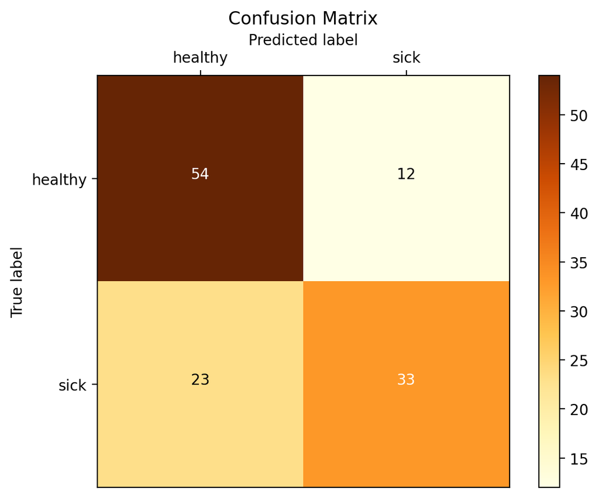

```python
# TODO
from sklearn import tree

clf = DecisionTreeClassifier(random_state=SEED)
clf.fit(train,target)
predicted = clf.predict(test)

print("%-12s %f" % ("Accuracy:", metrics.accuracy_score(target_test, predicted)))
print("Confusion Matrix: \n", metrics.confusion_matrix(target_test, predicted))
draw_confusion_matrix(target_test, predicted, ["healthy", "sick"])
```

### 1.2. [5 pts] Visualize the Decision Tree

Visualize the first two layers of the decision tree that you trained.

[output not shown]

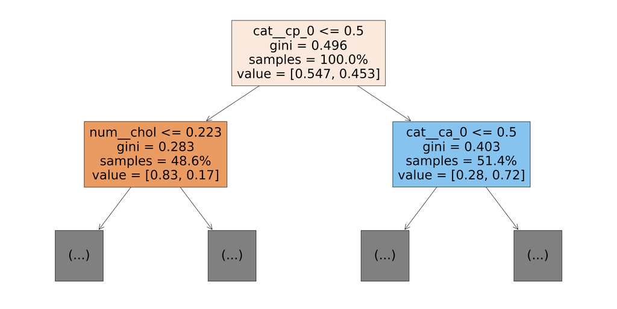

```python
# TODO
plt.figure(figsize=(30,15))
tree.plot_tree(clf, max_depth=1,proportion=True, feature_names=feature_names, filled=True)
```

**What is the gini index improvement of the first split?**

### 1.3 [5 pts] Plot the importance of each feature for the Decision Tree

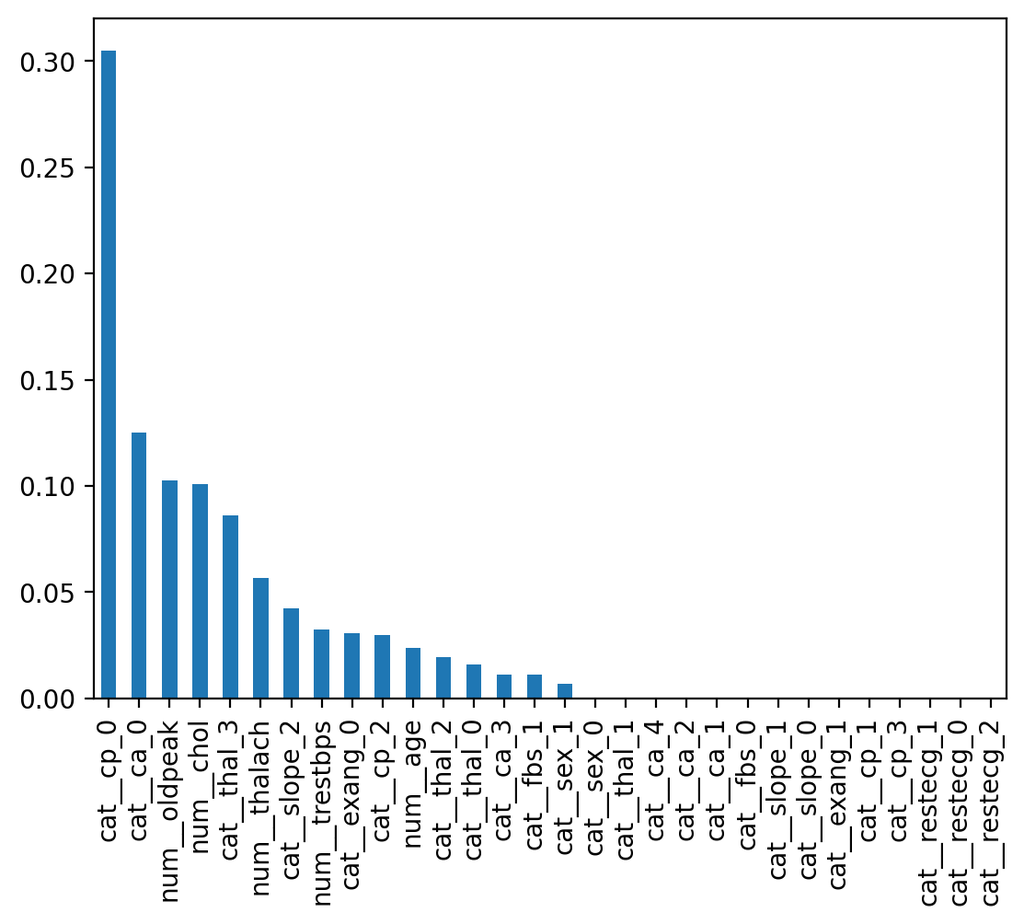

```python
# TODO
imp_pd = pd.Series(data=clf.feature_importances_, index=feature_names)
imp_pd = imp_pd.sort_values(ascending=False)
imp_pd.plot.bar()
```

**How many features have non-zero importance for the Decision Tree? If we remove the features with zero importance, will it change the decision tree for the same sampled dataset?**

Response: In total there are 16 features which have non-zero importance. Features with zero importance do not change the decision tree at all and can be removed without altering the decision tree, since as stated, they have zero importance and thus have no affect on the algorithm.

### 1.4 [10 pts] Optimize Decision Tree

While the default Decision Tree performs fairly well on the data, lets see if we can improve performance by optimizing the parameters.

Run a `GridSearchCV` with 5-Fold Cross Validation for the Decision Tree. Find the best model parameters for accuracy amongst the following:

- `max_depth` = [2, 4, 8, 16, 32]
- `min_samples_split` = [2, 4, 8, 16]
- `criterion` = [`gini`, `entropy`]

After using `GridSearchCV`, Print the **best 5 models** with the following parameters: `rank_test_score`, `param_max_depth`, `param_min_samples_split`, `param_criterion`, `mean_test_score`, `std_test_score`.

```python
# TODO
parameters = [
    {
        "max_depth": [2,4,8,16,32],
        "min_samples_split": [2,4,8,16],
        "criterion": ["gini", "entropy"],
    },
]

kf = KFold(n_splits=5, random_state=None)
grid = GridSearchCV(clf, parameters, cv=kf, scoring="accuracy")
grid.fit(train,target)

target_params = ['rank_test_score', 'param_max_depth', 'param_min_samples_split', 'param_criterion', 'mean_test_score', 'std_test_score']
res = pd.DataFrame(grid.cv_results_).sort_values("rank_test_score", ascending=True)
res[target_params].head(5)
```

|  | rank_test_score | param_max_depth | param_min_samples_split | param_criterion | mean_test_score | std_test_score |
| --- | --- | --- | --- | --- | --- | --- |
| 17 | 1 | 32 | 4 | gini | 0.779429 | 0.086323 |
| 13 | 1 | 16 | 4 | gini | 0.779429 | 0.086323 |
| 9 | 1 | 8 | 4 | gini | 0.779429 | 0.086323 |
| 4 | 4 | 4 | 2 | gini | 0.768018 | 0.075518 |
| 12 | 5 | 16 | 2 | gini | 0.763063 | 0.099541 |

**Using the best model you have, report the test accuracy and print out the confusion matrix**

```
Accuracy:    0.688525
```

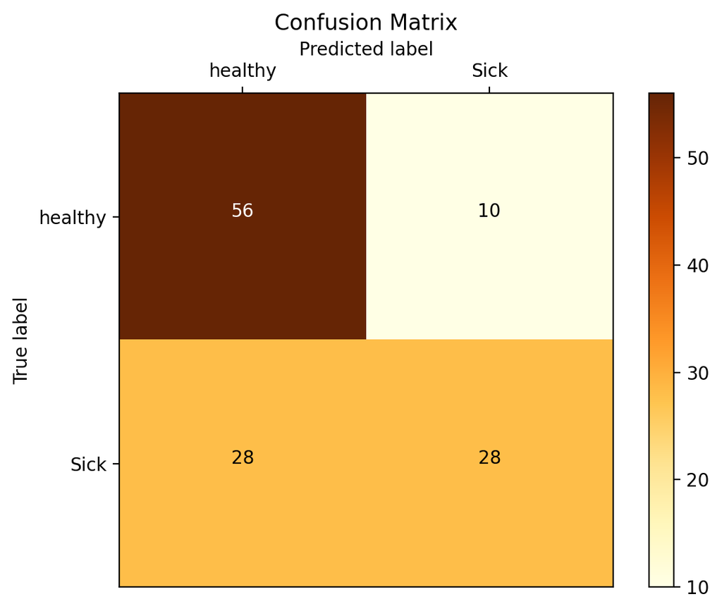

```python
# TODO
best = grid.best_estimator_
best.fit(train, target)
predicted = best.predict(test)

print("%-12s %f" % ('Accuracy:', metrics.accuracy_score(target_test, predicted)))
draw_confusion_matrix(target_test, predicted, ["healthy", "Sick"])
```

## 2. (20 pts) Multi-Layer Perceptron

### 2.1 [5 pts] Applying a Multi-Layer Perceptron

Apply the MLP on the **train data** with hidden_layer_sizes=(50, 50) and max_iter = 1000. **Report the accuracy and print the confusion matrix**. Make sure to set `random_state=SEED`.

```
Accuracy:    0.819672
Confusion Matrix:
 [[62  4]
 [18 38]]
```

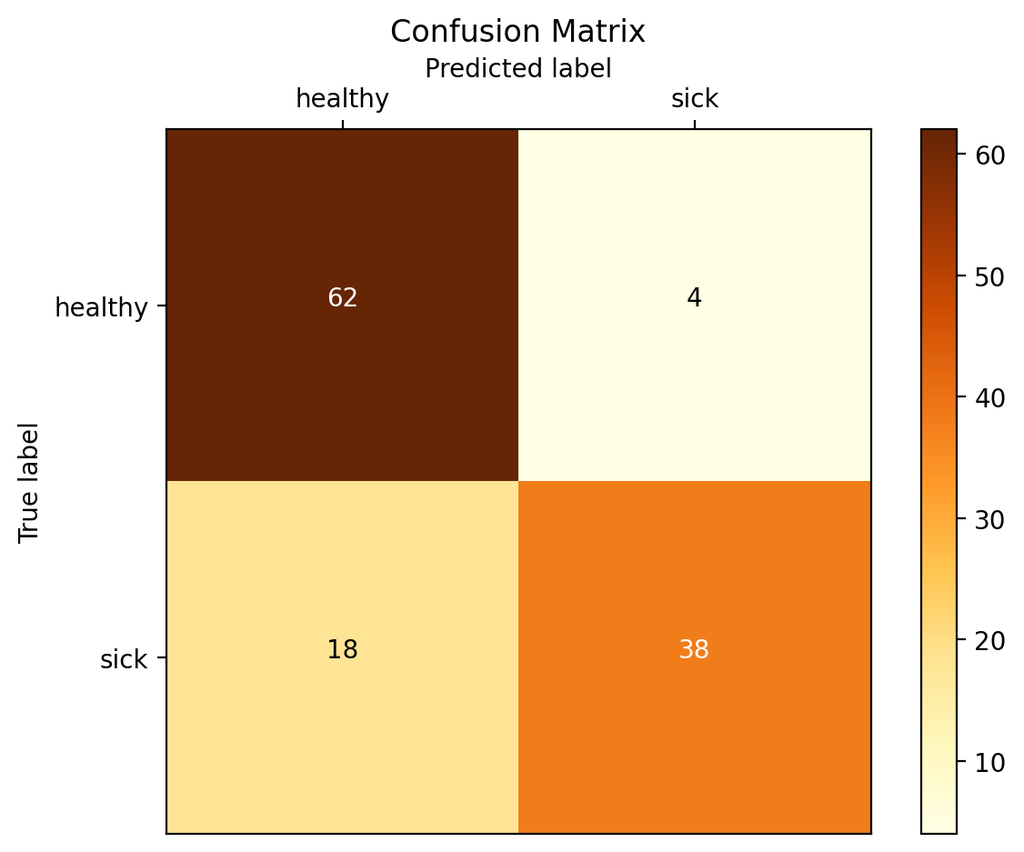

```python
# TODO
clf = MLPClassifier(hidden_layer_sizes=(50,50), max_iter=1000, random_state=SEED)
clf.fit(train,target)
predicted = clf.predict(test)

print("%-12s %f" % ("Accuracy:", metrics.accuracy_score(target_test, predicted)))
print("Confusion Matrix: \n", metrics.confusion_matrix(target_test, predicted))
draw_confusion_matrix(target_test, predicted, ["healthy", "sick"])
```

### 2.2 [10 pts] Speedtest between Decision Tree and MLP

Let us compare the training times and prediction times of a Decision Tree and an MLP. **Time how long it takes for a Decision Tree and an MLP to perform a .fit operation (i.e. training the model). Then, time how long it takes for a Decision Tree and an MLP to perform a .predict operation (i.e. predicting the testing data). Print out the timings and specify which model was quicker for each operation.** We recommend using the [time](https://docs.python.org/3/library/time.html) python module to time your code. An example of the time module was shown in project 2. Use the default Decision Tree Classifier and the MLP with the previously mentioned parameters.

```python
# TODO

dt = DecisionTreeClassifier(random_state=SEED)
mlp = MLPClassifier(hidden_layer_sizes=(50,50), max_iter=1000, random_state=SEED)

t0 = time.time()
dt.fit(train, target)
t1 = time.time()
print("DT Training Time : ", t1 - t0)

t0 = time.time()
mlp.fit(train, target)
t1 = time.time()
print("MLP Training Time : ", t1 - t0)
```

```
DT Training Time :  0.005543231964111328
MLP Training Time :  0.6761059761047363
```

Decision Trees were much quicker than the MLP.

### 2.3 [5 pts] Compare and contrast Decision Trees and MLPs.

**Describe at least one advantage and disadvantage of using an MLP over a Decision Tree.**

Response: MLP's take longer to train and require more compute, but can handle more complex, non-linear relationsships and patterns in the data.

## 3 (35 pts) PCA

### 3.1 [5 pts] Transform the train data using PCA

Train a PCA model to project the train data on the top 10 components. **Print out the 10 principal components**. Look at the documentation of [PCA](https://scikit-learn.org/stable/modules/generated/sklearn.decomposition.PCA.html) for reference.

```python
# TODO
pca = PCA(n_components=10)
pca_pipe = Pipeline(
    [
        (
            "scaler",
            StandardScaler(),
        ),  # Scikit learn PCA does not standardize so we need to add
        ("pca", pca),
    ]
)
pca_pipe.fit(train)
print(pca.components_)
```

```
[[ 0.18611809  0.14723377  0.0827966  -0.26958547  0.28724158 -0.08876141
   0.08876141  0.29373271 -0.18880161 -0.18588046  0.00547491 -0.03616204
   0.03616204  0.17165538 -0.18229389  0.04263397 -0.29674427  0.29674427
   0.12038936  0.23640547 -0.29624895 -0.19017656  0.06708592  0.13205351
   0.14006446 -0.08106023 -0.00461948  0.08832725 -0.26014306  0.21954194]
 [ 0.17782264  0.12934087  0.21781761  0.00085997 -0.00819057  0.47896852
  -0.47896852  0.01761698 -0.04673436  0.02638517 -0.01520276 -0.07185905
   0.07185905  0.32618016 -0.35610124  0.11900946  0.08021001 -0.08021001
  -0.05087735  0.09295655 -0.06752443  0.04033609 -0.06904782  0.0610647
   0.03216393 -0.13364728  0.02210197 -0.01976779  0.25112614 -0.25016493]
 [ 0.1113784   0.20923116 -0.08340017  0.07921133 -0.03404349 -0.2018614
   0.2018614  -0.17797524 -0.05583133  0.16476042  0.1340265  -0.5511467
   0.5511467   0.16551362 -0.14622474 -0.07456177  0.10682938 -0.10682938
   0.02514107 -0.12564882  0.11302289 -0.1552864   0.10431192  0.05430955
   0.04779555  0.03009288  0.05778072  0.08887376 -0.02385473 -0.03478466]
 [-0.0354728   0.25902106  0.07384051  0.19917574  0.21672998 -0.05117849
   0.05117849 -0.05916722  0.08173444 -0.16327904  0.27319757  0.09117566
  -0.09117566  0.07437116 -0.10230469  0.10978207  0.2768     -0.2768
   0.27081553 -0.10187863 -0.03320523  0.2913109  -0.46253951  0.0516882
   0.13021605 -0.03789029 -0.05916426  0.0925144  -0.24774416  0.21632863]
 [-0.09120263  0.04867001 -0.16181035 -0.16313074  0.05191553  0.13154099
  -0.13154099 -0.07616742  0.01404994  0.03585138  0.06481676 -0.27743322
   0.27743322 -0.33678475  0.30039026  0.14054336 -0.1202493   0.1202493
   0.03773732  0.28359868 -0.30220316  0.37441033 -0.24584018 -0.12520515
  -0.12582519 -0.08216671  0.22809992  0.09364128 -0.00517024 -0.09262433]
 [ 0.23307082  0.13298481  0.06645393 -0.14367125  0.22796243  0.14056155
  -0.14056155 -0.09547381 -0.18403626  0.36960395 -0.19049974  0.02293687
  -0.02293687 -0.32872864  0.24085064  0.34213852  0.13450707 -0.13450707
   0.22217753 -0.14046632  0.02960144 -0.25716438  0.07215712  0.00252155
   0.26635924  0.19015126 -0.06802427 -0.10381656 -0.03201311  0.10175308]
 [ 0.13085041 -0.04575547 -0.22681007 -0.12219539 -0.03489723 -0.13260932
   0.13260932 -0.0345588  -0.01999381 -0.02700035  0.13552365  0.13776979
  -0.13776979 -0.0294488  -0.02098806  0.19728225  0.25071585 -0.25071585
  -0.12632303  0.29187912 -0.22868895 -0.17759453  0.03986722  0.22017285
  -0.09627945  0.17524083 -0.12280017  0.49558508  0.09362784 -0.33006298]
 [-0.06057854 -0.04762676 -0.25470518 -0.066121    0.08963564 -0.04715481
   0.04715481  0.26192019  0.09891764 -0.16844768 -0.34155758 -0.03102717
   0.03102717  0.03440101 -0.09266925  0.2283075  -0.11375503  0.11375503
   0.4027465  -0.40278097  0.20170459  0.08092845 -0.06956298 -0.02784671
   0.03537828 -0.08045318  0.05552359  0.29333321  0.15082035 -0.31988296]
 [-0.02460261 -0.02264009 -0.05736137  0.02458658 -0.04154146  0.18141881
  -0.18141881  0.2411226   0.10906297 -0.20323966 -0.25847479 -0.1271958
   0.1271958  -0.14610735  0.2077026  -0.24197382  0.09125688 -0.09125688
  -0.24611375 -0.03527912  0.15794758 -0.19074927 -0.2596861   0.56539207
   0.0541471   0.03303556  0.08050687  0.09757573 -0.18226449  0.11718802]
 [ 0.08800402 -0.21217329  0.14694927 -0.11066296 -0.14357307 -0.05776048
   0.05776048  0.05206411  0.41875816 -0.2528875  -0.22931487 -0.11993696
   0.11993696 -0.02847204 -0.00386701  0.12643811  0.191856   -0.191856
  -0.13052738  0.16279614 -0.09760494 -0.0266236   0.08595074 -0.37887698
   0.47800008 -0.16289395 -0.0602162   0.01667568 -0.06317466  0.06842021]]
```

### 3.2 [5 pts] Percentage of variance explained by top 10 principal components

Using PCA's "explained_variance_ratio_", print the percentage of variance explained by the top 10 principal components.

```python
# TODO
print(pca.explained_variance_ratio_)
```

```
[0.17626116 0.08915634 0.07963692 0.06307261 0.05597995 0.05167126
 0.04939192 0.04876524 0.0428602  0.04058251]
```

### 3.3 [5 pts] Transform the train and test data into train_pca and test_pca using PCA

Note: Use fit_transform for train and transform for test

```python
# TODO

train_pca = pca.fit_transform(train)
test_pca = pca.transform(test)
```

### 3.4 [5 pts] PCA+Decision Tree

Train the default Decision Tree Classifier using train_pca. **Report the accuracy using test_pca and print the confusion matrix**.

```
Accuracy with PCA
Accuracy:    0.811475
Confusion Matrix:
 [[59  7]
 [16 40]]
```

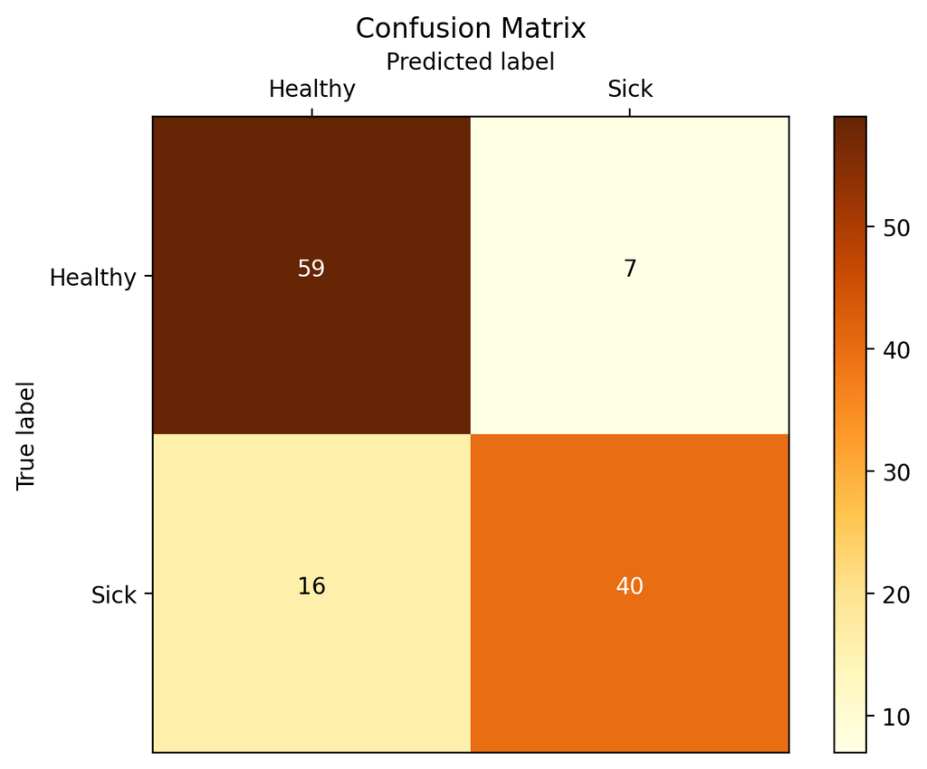

```python
# TODO
clf_pca = DecisionTreeClassifier(random_state=SEED)
clf_pca.fit(train_pca, target)
predicted = clf_pca.predict(test_pca)

print("Accuracy with PCA")
print("%-12s %f" % ("Accuracy:", metrics.accuracy_score(target_test, predicted)))
print("Confusion Matrix: \n", metrics.confusion_matrix(target_test, predicted))
draw_confusion_matrix(target_test, predicted, ["Healthy", "Sick"])
```

**Does the model perform better with or without PCA?**

Response: The model performs much bettwe with PCA with an over 10% boost in accuracy after applying PCA.

### 3.5 [5 pts] PCA+MLP

Train the MLP classifier with the same parameters as before using train_pca. **Report the accuracy using test_pca and print the confusion matrix**.

```
Accuracy with PCA
Accuracy:    0.803279
Confusion Matrix:
 [[61  5]
 [19 37]]
```

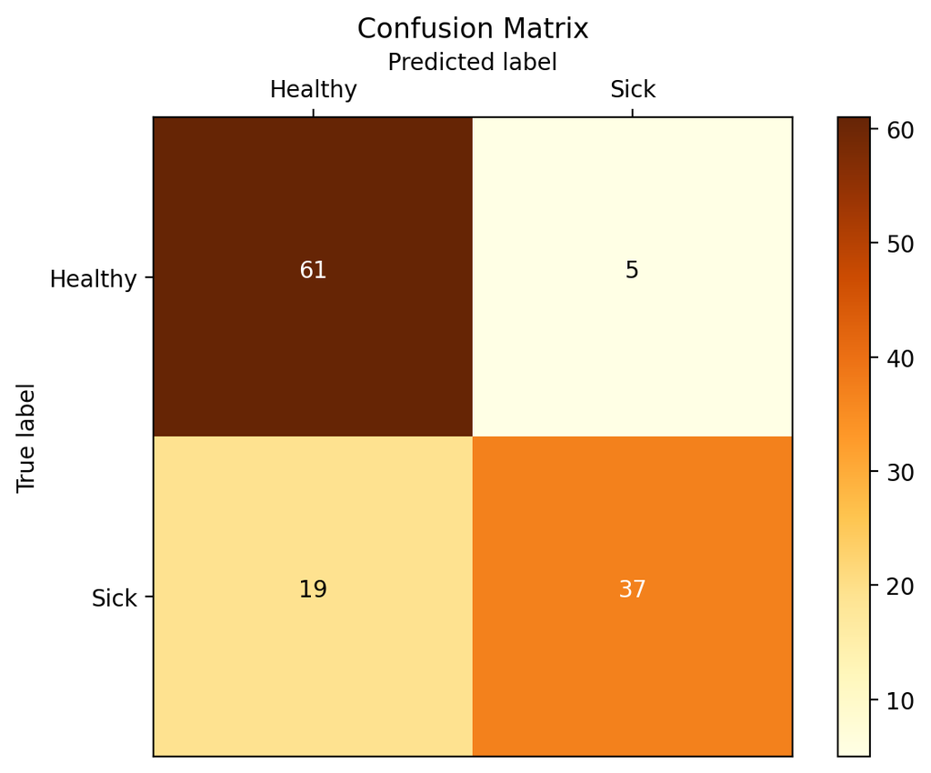

```python
# TODO
mlp_pca = MLPClassifier(hidden_layer_sizes=(50,50), max_iter=1000, random_state=SEED)
mlp_pca.fit(train_pca, target)
predicted = mlp_pca.predict(test_pca)

print("Accuracy with PCA")
print("%-12s %f" % ("Accuracy:", metrics.accuracy_score(target_test, predicted)))
print("Confusion Matrix: \n", metrics.confusion_matrix(target_test, predicted))
draw_confusion_matrix(target_test, predicted, ["Healthy", "Sick"])
```

**Does the model perform better with or without PCA?**

Response: This model performed slightly wotse after using PCA with around a 1% loss in accuracy.

### 3.6 [10 pts] Pros and Cons of PCA

**In your own words, provide at least two pros and at least two cons for using PCA**

Response: PCA is great for dimensionality reduction which can lead to reducing noise in the data and helps models focus on the main features leading to trends in the data. Also, PCA can remove multicollinearity, a key part in helping model data better. But, PCA can remove to much of the data, reducing models performance by removing components key to the model, removed for having low variance. Also, this a linear reduction technique so id the dataset does not have a linear decision boundary, PCA will not help at all.

## 4. (20 pts) K-Means Clustering

### 4.1 [5 pts] Apply K-means to the train data and print out the Inertia score

Use n_cluster = 5 and `random_state = SEED`.

```python
# TODO
kmeans = KMeans(n_clusters=5, random_state=SEED)
kmeans.fit(train)
print(f"Inertia Score:{kmeans.inertia_}")
```

```
Inertia Score:489.0488065162732
```

### 4.2 [10 pts] Find the optimal cluster size using the elbow method.

Use the elbow method to find the best cluster size or range of best cluster sizes for the train data. Check the cluster sizes from 2 to 25. Make sure to plot the Inertia and state where you think the elbow starts. Make sure to use `random_state = SEED`.

```
Inertia for K = 2: 619.2954019046072
Inertia for K = 3: 561.5278841368324
Inertia for K = 4: 515.0859158871034
Inertia for K = 5: 489.04880651627326
Inertia for K = 6: 470.33014819814787
Inertia for K = 7: 444.00021583021544
Inertia for K = 8: 426.3013305650318
Inertia for K = 9: 407.75246588206994
Inertia for K = 10: 401.96228381959475
Inertia for K = 11: 387.55286376836426
Inertia for K = 12: 371.7447692166255
Inertia for K = 13: 359.21875024779405
Inertia for K = 14: 350.70140597033185
Inertia for K = 15: 348.5128339576984
Inertia for K = 16: 342.60224115848393
Inertia for K = 17: 328.4880145733202
Inertia for K = 18: 319.4091985374208
Inertia for K = 19: 310.6815040643602
Inertia for K = 20: 304.1670627708047
Inertia for K = 21: 296.2499375298579
Inertia for K = 22: 288.42807171722495
Inertia for K = 23: 280.9185553969854
Inertia for K = 24: 271.0612652241275
```

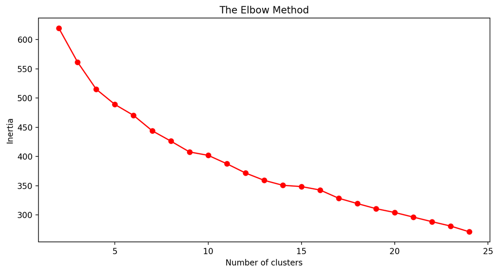

```python
# TODO
ks = list(range(2, 25))

inertia = []
for k in ks:
    kmeans = KMeans(n_clusters=k, init="k-means++", random_state=SEED)
    kmeans.fit(train)
    # inertia method returns wcss for that model
    inertia.append(kmeans.inertia_)
    print(f"Inertia for K = {k}: {kmeans.inertia_}")

plt.figure(figsize=(10, 5))
plt.plot(ks, inertia, marker="o", color="red")
plt.title("The Elbow Method")
plt.xlabel("Number of clusters")
plt.ylabel("Inertia")
plt.show()
```

Although K-Means clustering does not seem like good fit for our data, the elbow seems to be at around 6 clusters since this is when the slope started to decrease the most and points become closer together.

### 4.3 [5 pts] Find the optimal cluster size for the train_pca data

Repeat the same experiment but use train_pca instead of train.

```
Inertia for K = 2: 526.8986473659902
Inertia for K = 3: 481.68331476211074
Inertia for K = 4: 433.93185987666993
Inertia for K = 5: 411.36968943504326
Inertia for K = 6: 375.1867871970702
Inertia for K = 7: 382.89919979252363
Inertia for K = 8: 342.3458233480021
Inertia for K = 9: 325.73232432730373
Inertia for K = 10: 310.2418151821646
Inertia for K = 11: 287.7537700262638
Inertia for K = 12: 290.9020452246428
Inertia for K = 13: 278.22459380391615
Inertia for K = 14: 264.2275350235982
Inertia for K = 15: 256.3164359685783
Inertia for K = 16: 243.8877943092183
Inertia for K = 17: 233.951678383709
Inertia for K = 18: 229.9404407582009
Inertia for K = 19: 227.5745255599991
Inertia for K = 20: 220.3989336720402
Inertia for K = 21: 213.25908756269746
Inertia for K = 22: 205.80054892550046
Inertia for K = 23: 196.45100530250517
Inertia for K = 24: 193.0105928950394
```

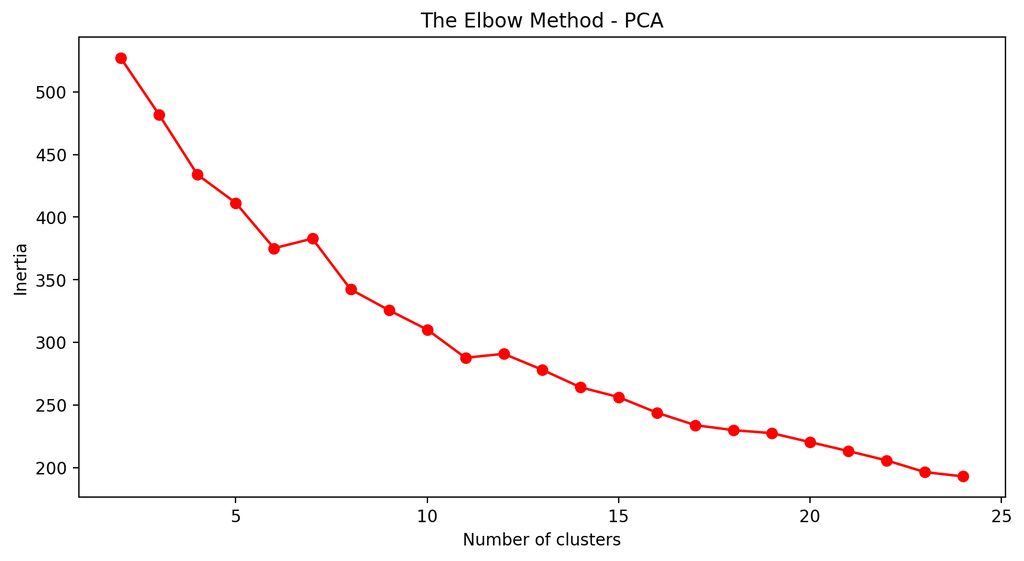

```python
# TODO
ks = list(range(2, 25))

inertia = []
for k in ks:
    kmeans = KMeans(n_clusters=k, init="k-means++", random_state=SEED)
    kmeans.fit(train_pca)
    # inertia method returns wcss for that model
    inertia.append(kmeans.inertia_)
    print(f"Inertia for K = {k}: {kmeans.inertia_}")

plt.figure(figsize=(10, 5))
plt.plot(ks, inertia, marker="o", color="red")
plt.title("The Elbow Method - PCA")
plt.xlabel("Number of clusters")
plt.ylabel("Inertia")
plt.show()
```

Similar to the previous experiment, we can guess that the best cluster size is somewhere between 5 and 10. Additionally, we see that the inertia is much smaller for every cluster size when using PCA features.